# Part I - San Francisco Ford GoBikes Analysis

## Introduction

> This data set includes information about individual rides made in a bike-sharing system covering the greater San Francisco Bay area. This dataset includes information about individual rides made in a bike-sharing system covering the greater San Francisco Bay area.The Ford GoBike services is a bike sharing transportation provided by Ford that is easy to use, enjoyable and convenient. The dataset contains the 2019 for the month of February records which has 183,412 records and 16 features. I am going to be carrying out exploratory and explanatory data analysis on the dataset.

## Preliminary Wrangling

```python
# import all packages and set plots to be embedded inline
import numpy as np
import pandas as pd
import matplotlib.pyplot as plt
import seaborn as sb
import datetime
import calendar
import math

%matplotlib inline
```

```python
ford_bikes = pd.read_csv('201902-fordgobike-tripdata(1).csv')
```

```python
ford_bikes.head()
```

|  | duration_sec | start_time | end_time | start_station_id | start_station_name | start_station_latitude | start_station_longitude | end_station_id | end_station_name | end_station_latitude | end_station_longitude | bike_id | user_type | member_birth_year | member_gender | bike_share_for_all_trip |
| --- | --- | --- | --- | --- | --- | --- | --- | --- | --- | --- | --- | --- | --- | --- | --- | --- |
| 0 | 52185 | 2019-02-28 17:32:10.1450 | 2019-03-01 08:01:55.9750 | 21.0 | Montgomery St BART Station (Market St at 2nd St) | 37.789625 | -122.400811 | 13.0 | Commercial St at Montgomery St | 37.794231 | -122.402923 | 4902 | Customer | 1984.0 | Male | No |
| 1 | 42521 | 2019-02-28 18:53:21.7890 | 2019-03-01 06:42:03.0560 | 23.0 | The Embarcadero at Steuart St | 37.791464 | -122.391034 | 81.0 | Berry St at 4th St | 37.775880 | -122.393170 | 2535 | Customer | NaN | NaN | No |
| 2 | 61854 | 2019-02-28 12:13:13.2180 | 2019-03-01 05:24:08.1460 | 86.0 | Market St at Dolores St | 37.769305 | -122.426826 | 3.0 | Powell St BART Station (Market St at 4th St) | 37.786375 | -122.404904 | 5905 | Customer | 1972.0 | Male | No |
| 3 | 36490 | 2019-02-28 17:54:26.0100 | 2019-03-01 04:02:36.8420 | 375.0 | Grove St at Masonic Ave | 37.774836 | -122.446546 | 70.0 | Central Ave at Fell St | 37.773311 | -122.444293 | 6638 | Subscriber | 1989.0 | Other | No |
| 4 | 1585 | 2019-02-28 23:54:18.5490 | 2019-03-01 00:20:44.0740 | 7.0 | Frank H Ogawa Plaza | 37.804562 | -122.271738 | 222.0 | 10th Ave at E 15th St | 37.792714 | -122.248780 | 4898 | Subscriber | 1974.0 | Male | Yes |

### What is the structure of your dataset?

> The dataset contains 183412 rows and 16 features

### What is/are the main feature(s) of interest in your dataset?

- Start time
- User type
- Start and end stations
- duration
- gender
- age

### What features in the dataset do you think will help support your investigation into your feature(s) of interest?

> start_station_name, end_station_name, member_gender, user_type, duration, start_time, member_birth_year

## Assessing the data

```python
ford_bikes.shape
```

```
(183412, 16)
```

```python
ford_bikes.info()
```

```
<class 'pandas.core.frame.DataFrame'>
RangeIndex: 183412 entries, 0 to 183411
Data columns (total 16 columns):
duration_sec               183412 non-null int64
start_time                 183412 non-null object
end_time                   183412 non-null object
start_station_id           183215 non-null float64
start_station_name         183215 non-null object
start_station_latitude     183412 non-null float64
start_station_longitude    183412 non-null float64
end_station_id             183215 non-null float64
end_station_name           183215 non-null object
end_station_latitude       183412 non-null float64
end_station_longitude      183412 non-null float64
bike_id                    183412 non-null int64
user_type                  183412 non-null object
member_birth_year          175147 non-null float64
member_gender              175147 non-null object
bike_share_for_all_trip    183412 non-null object
dtypes: float64(7), int64(2), object(7)
memory usage: 22.4+ MB
```

```python
#check for duplicated values
ford_bikes.duplicated().sum()
```

```
0
```

```python
#check for null values
ford_bikes.isnull().sum()
```

```
duration_sec                  0
start_time                    0
end_time                      0
start_station_id            197
start_station_name          197
start_station_latitude        0
start_station_longitude       0
end_station_id              197
end_station_name            197
end_station_latitude          0
end_station_longitude         0
bike_id                       0
user_type                     0
member_birth_year          8265
member_gender              8265
bike_share_for_all_trip       0
dtype: int64
```

```python
#unique values in the user type
ford_bikes['user_type'].unique()
```

```
array(['Customer', 'Subscriber'], dtype=object)
```

```python
#unique values in the gender
ford_bikes['member_gender'].unique()
```

```
array(['Male', nan, 'Other', 'Female'], dtype=object)
```

```python
ford_bikes.dtypes
```

```
duration_sec                 int64
start_time                  object
end_time                    object
start_station_id           float64
start_station_name          object
start_station_latitude     float64
start_station_longitude    float64
end_station_id             float64
end_station_name            object
end_station_latitude       float64
end_station_longitude      float64
bike_id                      int64
user_type                   object
member_birth_year          float64
member_gender               object
bike_share_for_all_trip     object
dtype: object
```

### Observations from the dataset

> Some quality and tidiness issues were observed in the dataset.
> - Wrong/incorrect datatypes: start_time and end_time datatypes should be converted to datetime datatypes. The user_type, member_gender and bike_share_for_all_trip should be converted to categorical datatypes. Bike_id, start_station_id, end_station_id should be converted to string datatype. Member_birth_year should be converted to int datatype.
> - minutes should be extracted from duraration and start_time variable should be splitted into hour of the day, day of the week and month of the year.
> - Member ages should be derived from member birth year

## Data Cleaning

```python
#make a copy of the original dataset
ford_bikes_clean = ford_bikes.copy()
```

```python
#convert datatypes

#start time and end_time variables to datetime datatype
ford_bikes_clean['start_time'] = pd.to_datetime(ford_bikes_clean['start_time'])
ford_bikes_clean['end_time'] = pd.to_datetime(ford_bikes_clean['end_time'])

#user_type, member_gender, bike_share to categorical datatype
for col in ['member_gender', 'user_type', 'bike_share_for_all_trip']:
    ford_bikes_clean[col] = ford_bikes_clean[col].astype('category')

#bike_id, start_station_id, end_station_id to string datatype
for bse in ['bike_id', 'start_station_id', 'end_station_id']:
    ford_bikes_clean[bse] = ford_bikes_clean[bse].astype('object')

#member_birth_year to int
#drop rows with null values
ford_bikes_clean = ford_bikes_clean.dropna(subset = ['member_birth_year'])
ford_bikes_clean['member_birth_year'] = ford_bikes_clean['member_birth_year'].astype('int')
```

```python
#confirm change
ford_bikes_clean.dtypes
```

```
duration_sec                        int64
start_time                 datetime64[ns]
end_time                   datetime64[ns]
start_station_id                   object
start_station_name                 object
start_station_latitude            float64
start_station_longitude           float64
end_station_id                     object
end_station_name                   object
end_station_latitude              float64
end_station_longitude             float64
bike_id                            object
user_type                        category
member_birth_year                   int64
member_gender                    category
bike_share_for_all_trip          category
dtype: object
```

```python
#extract minutes from duration and split the start_time variables into hour of the day, day of the week and month of the year
ford_bikes_clean['duration_minutes'] = ford_bikes_clean['duration_sec']/60

ford_bikes_clean['start_hour_num'] = ford_bikes_clean['start_time'].apply(lambda time: time.hour)
ford_bikes_clean['start_hour_name'] = 'morning'
ford_bikes_clean['start_hour_name'][(ford_bikes_clean['start_hour_num'] >=12) & (ford_bikes_clean['start_hour_num'] <= 17)] = 'afternoon'
ford_bikes_clean['start_hour_name'][(ford_bikes_clean['start_hour_num'] >=18) & (ford_bikes_clean['start_hour_num'] <= 23)] = 'night'


ford_bikes_clean['start_day_of_week'] = ford_bikes_clean.start_time.dt.strftime('%A')
ford_bikes_clean['start_month_name'] = ford_bikes_clean.start_time.dt.strftime('%b')
ford_bikes_clean.head(10)
```

|  | duration_sec | start_time | end_time | start_station_id | start_station_name | start_station_latitude | start_station_longitude | end_station_id | end_station_name | end_station_latitude | ... | bike_id | user_type | member_birth_year | member_gender | bike_share_for_all_trip | duration_minutes | start_hour_num | start_hour_name | start_day_of_week | start_month_name |
| --- | --- | --- | --- | --- | --- | --- | --- | --- | --- | --- | --- | --- | --- | --- | --- | --- | --- | --- | --- | --- | --- |
| 0 | 52185 | 2019-02-28 17:32:10.145 | 2019-03-01 08:01:55.975 | 21 | Montgomery St BART Station (Market St at 2nd St) | 37.789625 | -122.400811 | 13 | Commercial St at Montgomery St | 37.794231 | ... | 4902 | Customer | 1984 | Male | No | 869.750000 | 17 | afternoon | Thursday | Feb |
| 2 | 61854 | 2019-02-28 12:13:13.218 | 2019-03-01 05:24:08.146 | 86 | Market St at Dolores St | 37.769305 | -122.426826 | 3 | Powell St BART Station (Market St at 4th St) | 37.786375 | ... | 5905 | Customer | 1972 | Male | No | 1030.900000 | 12 | afternoon | Thursday | Feb |
| 3 | 36490 | 2019-02-28 17:54:26.010 | 2019-03-01 04:02:36.842 | 375 | Grove St at Masonic Ave | 37.774836 | -122.446546 | 70 | Central Ave at Fell St | 37.773311 | ... | 6638 | Subscriber | 1989 | Other | No | 608.166667 | 17 | afternoon | Thursday | Feb |
| 4 | 1585 | 2019-02-28 23:54:18.549 | 2019-03-01 00:20:44.074 | 7 | Frank H Ogawa Plaza | 37.804562 | -122.271738 | 222 | 10th Ave at E 15th St | 37.792714 | ... | 4898 | Subscriber | 1974 | Male | Yes | 26.416667 | 23 | night | Thursday | Feb |
| 5 | 1793 | 2019-02-28 23:49:58.632 | 2019-03-01 00:19:51.760 | 93 | 4th St at Mission Bay Blvd S | 37.770407 | -122.391198 | 323 | Broadway at Kearny | 37.798014 | ... | 5200 | Subscriber | 1959 | Male | No | 29.883333 | 23 | night | Thursday | Feb |
| 6 | 1147 | 2019-02-28 23:55:35.104 | 2019-03-01 00:14:42.588 | 300 | Palm St at Willow St | 37.317298 | -121.884995 | 312 | San Jose Diridon Station | 37.329732 | ... | 3803 | Subscriber | 1983 | Female | No | 19.116667 | 23 | night | Thursday | Feb |
| 7 | 1615 | 2019-02-28 23:41:06.766 | 2019-03-01 00:08:02.756 | 10 | Washington St at Kearny St | 37.795393 | -122.404770 | 127 | Valencia St at 21st St | 37.756708 | ... | 6329 | Subscriber | 1989 | Male | No | 26.916667 | 23 | night | Thursday | Feb |
| 8 | 1570 | 2019-02-28 23:41:48.790 | 2019-03-01 00:07:59.715 | 10 | Washington St at Kearny St | 37.795393 | -122.404770 | 127 | Valencia St at 21st St | 37.756708 | ... | 6548 | Subscriber | 1988 | Other | No | 26.166667 | 23 | night | Thursday | Feb |
| 9 | 1049 | 2019-02-28 23:49:47.699 | 2019-03-01 00:07:17.025 | 19 | Post St at Kearny St | 37.788975 | -122.403452 | 121 | Mission Playground | 37.759210 | ... | 6488 | Subscriber | 1992 | Male | No | 17.483333 | 23 | night | Thursday | Feb |
| 10 | 458 | 2019-02-28 23:57:57.211 | 2019-03-01 00:05:35.435 | 370 | Jones St at Post St | 37.787327 | -122.413278 | 43 | San Francisco Public Library (Grove St at Hyde... | 37.778768 | ... | 5318 | Subscriber | 1996 | Female | Yes | 7.633333 | 23 | night | Thursday | Feb |

10 rows × 21 columns

```python
#check value counts of new columns
print(ford_bikes_clean['start_hour_num'].value_counts())
print(ford_bikes_clean['start_hour_name'].value_counts())
print(ford_bikes_clean['start_day_of_week'].value_counts())
```

```
17    20921
8     20242
18    16133
9     15221
16    13492
7     10235
19     9432
15     8657
12     8237
13     8118
10     7980
14     7694
11     7473
20     6220
21     4401
6      3294
22     2793
23     1573
0       893
5       866
1       525
2       356
4       227
3       164
Name: start_hour_num, dtype: int64
morning      67476
afternoon    67119
night        40552
Name: start_hour_name, dtype: int64
Thursday     33733
Tuesday      30616
Wednesday    28456
Friday       27682
Monday       25686
Sunday       14532
Saturday     14442
Name: start_day_of_week, dtype: int64
```

```python
#derive member ages from birth year
ford_bikes_clean['member_Age'] = ford_bikes_clean['member_birth_year'].apply(lambda x: 2019 - x)
```

```python
#confirm results
ford_bikes_clean['member_Age'].describe()
```

```
count    175147.000000
mean         34.193563
std          10.116689
min          18.000000
25%          27.000000
50%          32.000000
75%          39.000000
max         141.000000
Name: member_Age, dtype: float64
```

```python
#let's take another glance at the cleaned dataset
ford_bikes_clean.head(20)
```

|  | duration_sec | start_time | end_time | start_station_id | start_station_name | start_station_latitude | start_station_longitude | end_station_id | end_station_name | end_station_latitude | ... | user_type | member_birth_year | member_gender | bike_share_for_all_trip | duration_minutes | start_hour_num | start_hour_name | start_day_of_week | start_month_name | member_Age |
| --- | --- | --- | --- | --- | --- | --- | --- | --- | --- | --- | --- | --- | --- | --- | --- | --- | --- | --- | --- | --- | --- |
| 0 | 52185 | 2019-02-28 17:32:10.145 | 2019-03-01 08:01:55.975 | 21 | Montgomery St BART Station (Market St at 2nd St) | 37.789625 | -122.400811 | 13 | Commercial St at Montgomery St | 37.794231 | ... | Customer | 1984 | Male | No | 869.750000 | 17 | afternoon | Thursday | Feb | 35 |
| 2 | 61854 | 2019-02-28 12:13:13.218 | 2019-03-01 05:24:08.146 | 86 | Market St at Dolores St | 37.769305 | -122.426826 | 3 | Powell St BART Station (Market St at 4th St) | 37.786375 | ... | Customer | 1972 | Male | No | 1030.900000 | 12 | afternoon | Thursday | Feb | 47 |
| 3 | 36490 | 2019-02-28 17:54:26.010 | 2019-03-01 04:02:36.842 | 375 | Grove St at Masonic Ave | 37.774836 | -122.446546 | 70 | Central Ave at Fell St | 37.773311 | ... | Subscriber | 1989 | Other | No | 608.166667 | 17 | afternoon | Thursday | Feb | 30 |
| 4 | 1585 | 2019-02-28 23:54:18.549 | 2019-03-01 00:20:44.074 | 7 | Frank H Ogawa Plaza | 37.804562 | -122.271738 | 222 | 10th Ave at E 15th St | 37.792714 | ... | Subscriber | 1974 | Male | Yes | 26.416667 | 23 | night | Thursday | Feb | 45 |
| 5 | 1793 | 2019-02-28 23:49:58.632 | 2019-03-01 00:19:51.760 | 93 | 4th St at Mission Bay Blvd S | 37.770407 | -122.391198 | 323 | Broadway at Kearny | 37.798014 | ... | Subscriber | 1959 | Male | No | 29.883333 | 23 | night | Thursday | Feb | 60 |
| 6 | 1147 | 2019-02-28 23:55:35.104 | 2019-03-01 00:14:42.588 | 300 | Palm St at Willow St | 37.317298 | -121.884995 | 312 | San Jose Diridon Station | 37.329732 | ... | Subscriber | 1983 | Female | No | 19.116667 | 23 | night | Thursday | Feb | 36 |
| 7 | 1615 | 2019-02-28 23:41:06.766 | 2019-03-01 00:08:02.756 | 10 | Washington St at Kearny St | 37.795393 | -122.404770 | 127 | Valencia St at 21st St | 37.756708 | ... | Subscriber | 1989 | Male | No | 26.916667 | 23 | night | Thursday | Feb | 30 |
| 8 | 1570 | 2019-02-28 23:41:48.790 | 2019-03-01 00:07:59.715 | 10 | Washington St at Kearny St | 37.795393 | -122.404770 | 127 | Valencia St at 21st St | 37.756708 | ... | Subscriber | 1988 | Other | No | 26.166667 | 23 | night | Thursday | Feb | 31 |
| 9 | 1049 | 2019-02-28 23:49:47.699 | 2019-03-01 00:07:17.025 | 19 | Post St at Kearny St | 37.788975 | -122.403452 | 121 | Mission Playground | 37.759210 | ... | Subscriber | 1992 | Male | No | 17.483333 | 23 | night | Thursday | Feb | 27 |
| 10 | 458 | 2019-02-28 23:57:57.211 | 2019-03-01 00:05:35.435 | 370 | Jones St at Post St | 37.787327 | -122.413278 | 43 | San Francisco Public Library (Grove St at Hyde... | 37.778768 | ... | Subscriber | 1996 | Female | Yes | 7.633333 | 23 | night | Thursday | Feb | 23 |
| 11 | 506 | 2019-02-28 23:56:55.540 | 2019-03-01 00:05:21.733 | 44 | Civic Center/UN Plaza BART Station (Market St ... | 37.781074 | -122.411738 | 343 | Bryant St at 2nd St | 37.783172 | ... | Subscriber | 1993 | Male | No | 8.433333 | 23 | night | Thursday | Feb | 26 |
| 12 | 1176 | 2019-02-28 23:45:12.651 | 2019-03-01 00:04:49.184 | 127 | Valencia St at 21st St | 37.756708 | -122.421025 | 323 | Broadway at Kearny | 37.798014 | ... | Customer | 1990 | Male | No | 19.600000 | 23 | night | Thursday | Feb | 29 |
| 14 | 395 | 2019-02-28 23:56:26.848 | 2019-03-01 00:03:01.947 | 243 | Bancroft Way at College Ave | 37.869360 | -122.254337 | 252 | Channing Way at Shattuck Ave | 37.865847 | ... | Subscriber | 1988 | Male | No | 6.583333 | 23 | night | Thursday | Feb | 31 |
| 15 | 208 | 2019-02-28 23:59:18.548 | 2019-03-01 00:02:47.228 | 349 | Howard St at Mary St | 37.781010 | -122.405666 | 60 | 8th St at Ringold St | 37.774520 | ... | Subscriber | 1993 | Male | Yes | 3.466667 | 23 | night | Thursday | Feb | 26 |
| 16 | 548 | 2019-02-28 23:50:41.607 | 2019-02-28 23:59:49.953 | 131 | 22nd St at Dolores St | 37.755000 | -122.425728 | 71 | Broderick St at Oak St | 37.773063 | ... | Subscriber | 1981 | Male | No | 9.133333 | 23 | night | Thursday | Feb | 38 |
| 17 | 674 | 2019-02-28 23:48:25.095 | 2019-02-28 23:59:40.092 | 74 | Laguna St at Hayes St | 37.776435 | -122.426244 | 336 | Potrero Ave and Mariposa St | 37.763281 | ... | Subscriber | 1975 | Male | No | 11.233333 | 23 | night | Thursday | Feb | 44 |
| 18 | 557 | 2019-02-28 23:49:01.851 | 2019-02-28 23:58:19.809 | 321 | 5th St at Folsom | 37.780146 | -122.403071 | 75 | Market St at Franklin St | 37.773793 | ... | Subscriber | 1990 | Male | No | 9.283333 | 23 | night | Thursday | Feb | 29 |
| 19 | 874 | 2019-02-28 23:43:05.183 | 2019-02-28 23:57:39.796 | 180 | Telegraph Ave at 23rd St | 37.812678 | -122.268773 | 180 | Telegraph Ave at 23rd St | 37.812678 | ... | Customer | 1978 | Male | No | 14.566667 | 23 | night | Thursday | Feb | 41 |
| 20 | 417 | 2019-02-28 23:50:38.239 | 2019-02-28 23:57:35.852 | 72 | Page St at Scott St | 37.772406 | -122.435650 | 107 | 17th St at Dolores St | 37.763015 | ... | Subscriber | 1983 | Male | No | 6.950000 | 23 | night | Thursday | Feb | 36 |
| 21 | 414 | 2019-02-28 23:50:26.879 | 2019-02-28 23:57:21.130 | 163 | Lake Merritt BART Station | 37.797320 | -122.265320 | 221 | 6th Ave at E 12th St (Temporary Location) | 37.794396 | ... | Subscriber | 1984 | Male | Yes | 6.900000 | 23 | night | Thursday | Feb | 35 |

20 rows × 22 columns

```python
#store the cleaned datset in a csv file
ford_bikes_clean.to_csv('201902_fordgobike_tripdata_clean.csv', index=None)
```

## Univariate Exploration

> In this section, I am going to investigate distributions of individual variables. If I see unusual points or outliers, I would take a deeper look to clean things up and prepare to look at relationships between different variables.

I am going to be creating a list of user-defined functions

```python
#user-defined function for countplots
def countplot(ford_bikes_clean, column, order = None, color=None):
    plt.figure(figsize=[9,8])
    sb.countplot(data = ford_bikes_clean, x=column, color = color, order=order);
    plt.title(f'''Distribution of trip count based on {column}'''.title(), fontsize=12, weight ='bold')
    plt.xlabel(column.title(),fontsize=10, weight='bold')
    plt.ylabel('Trip Count'.title(),fontsize=10,weight='bold')
```

```python
#user-defined function for horizontal countplot
def countplot2(ford_bikes_clean, column, order = None, color=None):
    plt.figure(figsize=[9,8])
    sb.countplot(data = ford_bikes_clean, y=column, color = color, order=order);
    plt.title(f'''Distribution of trips based on {column}'''.title(), fontsize=12, weight ='bold')
    plt.ylabel(column.title(),fontsize=10, weight='bold')
    plt.xlabel('Trip Count'.title(),fontsize=10,weight='bold')
```

```python
#user-defined function for histogram
def histplot(ford_bikes_clean, column, bins=None, color=None):
    plt.figure(figsize=[10,8])
    plt.hist(data = ford_bikes_clean, x=column, color=color, bins=bins);
    plt.title(f'''Distribution of {column}'''.title(), fontsize=12, weight ='bold')
    plt.xlabel(column.title(),fontsize=10, weight='bold')
    plt.ylabel('Count'.title(),fontsize=10,weight='bold')
```

```python
#user-defined function for multi-variables plots
def bivariate(ford_bikes_clean, column, order = None, color=None,hue=None):
    plt.figure(figsize=[9,8])
    sb.countplot(data = ford_bikes_clean, y=column, color = color, order=order, hue=hue);
    plt.ylabel(column.title(),fontsize=10, weight='bold')
    plt.xlabel('Trip Count'.title(),fontsize=10,weight='bold')
```

```python
#user-defined function for barplots
def barplots(ford_bikes_clean, column, x=None, color=None, order=None, hue=None):
    plt.figure(figsize=[10,8])
    sb.barplot(data = ford_bikes_clean, y=column, x=x, order=order, color=color, hue=hue);
    plt.ylabel(column.title(),fontsize=10,weight='bold')
    plt.xlabel(x.title(),fontsize=10,weight='bold')
```

### 1. Distribution of trip count based on user_type

|  | user_type |
| --- | --- |
| Subscriber | 158516 |
| Customer | 16631 |

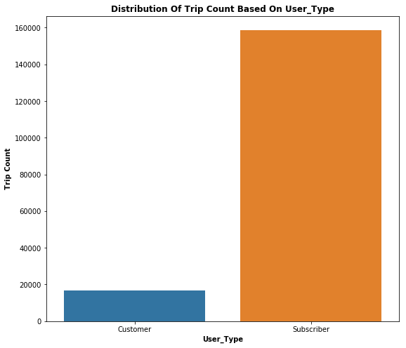

```python
countplot(ford_bikes_clean,'user_type')
pd.DataFrame(ford_bikes_clean['user_type'].value_counts())
```

### Observation

From the above plot, subscribers go on trips more than customers. That means the bike services have more subscribers than customers, maybe the subscription price is reasonable enough and the customers might be tourists.

### 2. Distribution of trips based on gender

|  | member_gender |
| --- | --- |
| Male | 130651 |
| Female | 40844 |
| Other | 3652 |

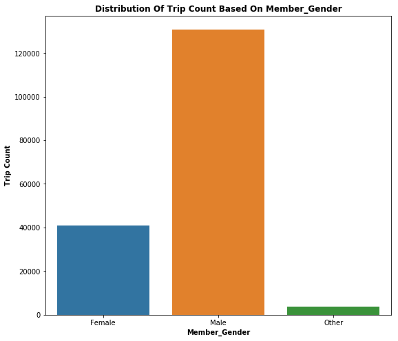

```python
countplot(ford_bikes_clean, 'member_gender')
pd.DataFrame(ford_bikes_clean['member_gender'].value_counts())
```

### Observation

The male gender takes trips more than other genders. Although, it is not specified what the "other" gender is, but I would assume its people who didnt reveal their gender during booking or registration. It may also mean that the men seem to enjoy using the bike services more.

### 3. Count of trips based on hour of the day and day of the week

|  | start_hour_name |
| --- | --- |
| morning | 67476 |
| afternoon | 67119 |
| night | 40552 |

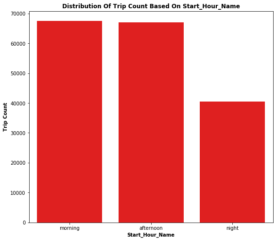

```python
#hour of the day
day_hour = ['morning', 'afternoon', 'night']
day_hour_order = pd.api.types.CategoricalDtype(ordered=True, categories=day_hour)
ford_bikes_clean['start_hour_name'] = ford_bikes_clean['start_hour_name'].astype(day_hour_order)

countplot(ford_bikes_clean, 'start_hour_name', color='red')
pd.DataFrame(ford_bikes_clean['start_hour_name'].value_counts())
```

|  | start_day_of_week |
| --- | --- |
| Thursday | 33733 |
| Tuesday | 30616 |
| Wednesday | 28456 |
| Friday | 27682 |
| Monday | 25686 |
| Sunday | 14532 |
| Saturday | 14442 |

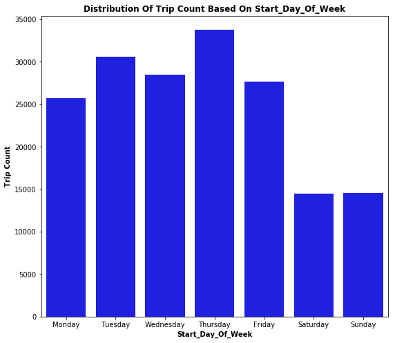

```python
#day of the week
week_day = ['Monday', 'Tuesday', 'Wednesday', 'Thursday', 'Friday', 'Saturday', 'Sunday']
week_day_order = pd.api.types.CategoricalDtype(ordered=True, categories=week_day)
ford_bikes_clean['start_day_of_week'] = ford_bikes_clean['start_day_of_week'].astype(week_day_order)

countplot(ford_bikes_clean, 'start_day_of_week', color='blue')
pd.DataFrame(ford_bikes_clean['start_day_of_week'].value_counts())
```

### Observation

1. It is observed that most trips are taken in the morning and in the afternoon than at night. This might mean that most riders prefer day rides to night rides, and most might have their engagements during the daytime.
2. During the week, most trips are taken on Monday to Friday, with Thursday being the highest. There are less trips during the weekends

### 4. Distribution of member age and count of trips based on age

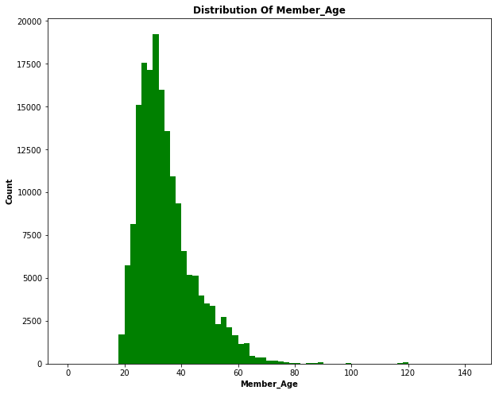

```python
bins = np.arange(0, ford_bikes_clean['member_Age'].max()+2, 2)
histplot(ford_bikes_clean, 'member_Age', bins=bins, color = 'green')
```

There are members with age above 100 years. I am going to treat this ages as outliers and drop ages that are above 90. Looking at the age distribution below, the maximum age is 141.

```python
ford_bikes_clean['member_Age'].describe()
```

```
count    175147.000000
mean         34.193563
std          10.116689
min          18.000000
25%          27.000000
50%          32.000000
75%          39.000000
max         141.000000
Name: member_Age, dtype: float64
```

```python
#drop Ages that are greater than 90
ford_bikes_clean.drop(ford_bikes_clean[ford_bikes_clean['member_Age'] > 90].index, inplace=True)
ford_bikes_clean['member_Age'].describe()
```

```
count    175070.000000
mean         34.157011
std           9.966723
min          18.000000
25%          27.000000
50%          32.000000
75%          39.000000
max          89.000000
Name: member_Age, dtype: float64
```

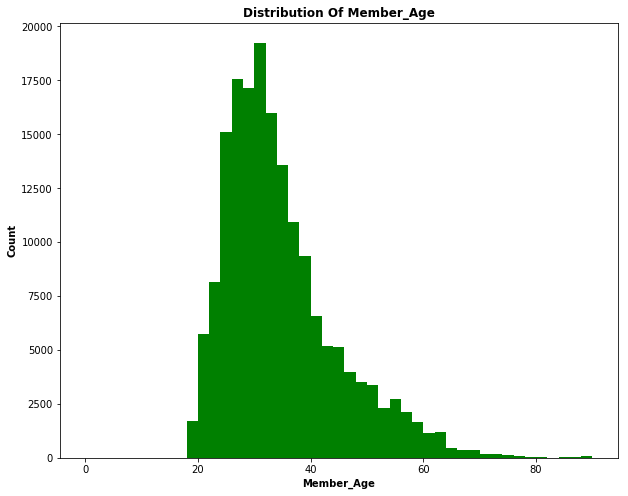

```python
#replot
bins = np.arange(0, ford_bikes_clean['member_Age'].max()+2, 2)
histplot(ford_bikes_clean, 'member_Age', bins=bins, color = 'green')
```

```python
#group the members according to age
age_group = pd.cut(x=ford_bikes_clean['member_Age'], bins=[0,18,41,53,65,89], labels = ['18 to 29', '30 to 41','42 to 53', '54 to 65', 'above 65'])

ford_bikes_clean.insert(22,'age_group', age_group)

ford_bikes_clean.head()
```

|  | duration_sec | start_time | end_time | start_station_id | start_station_name | start_station_latitude | start_station_longitude | end_station_id | end_station_name | end_station_latitude | ... | member_birth_year | member_gender | bike_share_for_all_trip | duration_minutes | start_hour_num | start_hour_name | start_day_of_week | start_month_name | member_Age | age_group |
| --- | --- | --- | --- | --- | --- | --- | --- | --- | --- | --- | --- | --- | --- | --- | --- | --- | --- | --- | --- | --- | --- |
| 0 | 52185 | 2019-02-28 17:32:10.145 | 2019-03-01 08:01:55.975 | 21 | Montgomery St BART Station (Market St at 2nd St) | 37.789625 | -122.400811 | 13 | Commercial St at Montgomery St | 37.794231 | ... | 1984 | Male | No | 869.750000 | 17 | afternoon | Thursday | Feb | 35 | 30 to 41 |
| 2 | 61854 | 2019-02-28 12:13:13.218 | 2019-03-01 05:24:08.146 | 86 | Market St at Dolores St | 37.769305 | -122.426826 | 3 | Powell St BART Station (Market St at 4th St) | 37.786375 | ... | 1972 | Male | No | 1030.900000 | 12 | afternoon | Thursday | Feb | 47 | 42 to 53 |
| 3 | 36490 | 2019-02-28 17:54:26.010 | 2019-03-01 04:02:36.842 | 375 | Grove St at Masonic Ave | 37.774836 | -122.446546 | 70 | Central Ave at Fell St | 37.773311 | ... | 1989 | Other | No | 608.166667 | 17 | afternoon | Thursday | Feb | 30 | 30 to 41 |
| 4 | 1585 | 2019-02-28 23:54:18.549 | 2019-03-01 00:20:44.074 | 7 | Frank H Ogawa Plaza | 37.804562 | -122.271738 | 222 | 10th Ave at E 15th St | 37.792714 | ... | 1974 | Male | Yes | 26.416667 | 23 | night | Thursday | Feb | 45 | 42 to 53 |
| 5 | 1793 | 2019-02-28 23:49:58.632 | 2019-03-01 00:19:51.760 | 93 | 4th St at Mission Bay Blvd S | 37.770407 | -122.391198 | 323 | Broadway at Kearny | 37.798014 | ... | 1959 | Male | No | 29.883333 | 23 | night | Thursday | Feb | 60 | 54 to 65 |

5 rows × 23 columns

|  | age_group |
| --- | --- |
| 30 to 41 | 141037 |
| 42 to 53 | 23452 |
| 54 to 65 | 9245 |
| above 65 | 1302 |
| 18 to 29 | 34 |

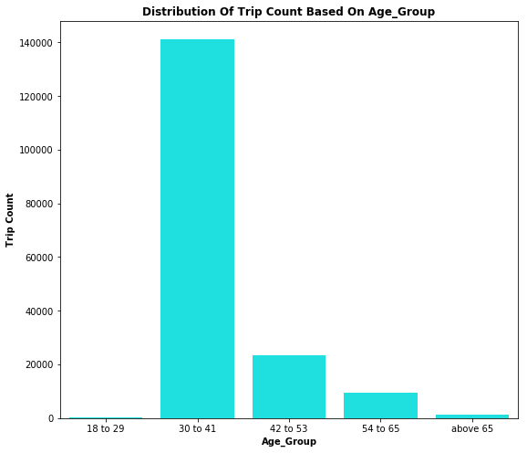

```python
#trip count based on age group
countplot(ford_bikes_clean, 'age_group', color = 'cyan')
pd.DataFrame(ford_bikes_clean['age_group'].value_counts())
```

### 5. Distribution of trip duration

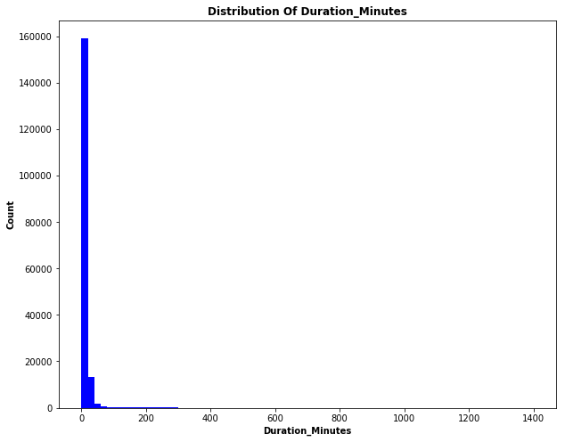

```python
bins = np.arange(0,1420,20)
histplot(ford_bikes_clean, 'duration_minutes', bins=bins, color = 'blue')
```

```python
ford_bikes_clean['duration_minutes'].describe()
```

```
count    175070.000000
mean         11.737286
std          27.365681
min           1.016667
25%           5.383333
50%           8.500000
75%          13.150000
max        1409.133333
Name: duration_minutes, dtype: float64
```

The maximum duration of rides in minutes is 1409 minutes, which is quite long for a bike ride. Let's take a look at the average

```python
print('The average duration of trips in minutes is', ford_bikes_clean['duration_minutes'].mean())
```

```
The average duration of trips in minutes is 11.7372862284
```

From the plot, there are trips that take more than 200 minutes (more than 3 hours), which is quite long for a bike trip. Someone would be so weary after such a trip. So I am going to treat trips than are more than 100 minutes as outliers.

```python
#drop duration trips that are more than 100 minutes
ford_bikes_clean.drop(ford_bikes_clean[ford_bikes_clean['duration_minutes'] > 100].index, inplace=True)
ford_bikes_clean['duration_minutes'].describe()
```

```
count    174365.000000
mean         10.567586
std           8.467036
min           1.016667
25%           5.366667
50%           8.483333
75%          13.066667
max          99.766667
Name: duration_minutes, dtype: float64
```

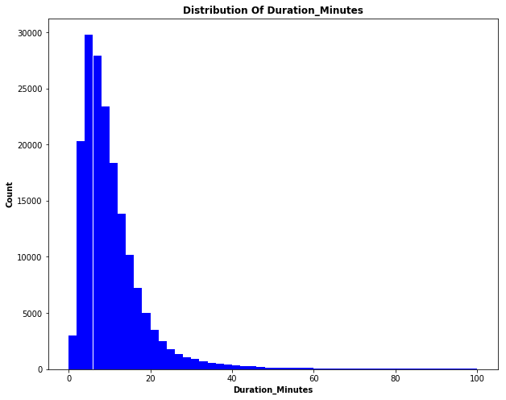

```python
#replot
bins = np.arange(0, ford_bikes_clean['duration_minutes'].max()+2, 2)
histplot(ford_bikes_clean, 'duration_minutes', bins=bins, color = 'blue')
```

### Observation

Most trips take an average of about 10 minutes, and a maximum of 99 minutes (after removing outliers). The count of trips that take 60 to 99 minutes is few, meaning that people take rides to closer locations.

### 6. Count of trips to top 10 start and end stations

|  | start_station_name |
| --- | --- |
| Market St at 10th St | 3640 |
| San Francisco Caltrain Station 2 (Townsend St at 4th St) | 3403 |
| Berry St at 4th St | 2940 |
| Montgomery St BART Station (Market St at 2nd St) | 2701 |
| Powell St BART Station (Market St at 4th St) | 2599 |
| San Francisco Caltrain (Townsend St at 4th St) | 2563 |
| San Francisco Ferry Building (Harry Bridges Plaza) | 2517 |
| Howard St at Beale St | 2214 |
| Steuart St at Market St | 2187 |
| Powell St BART Station (Market St at 5th St) | 2119 |

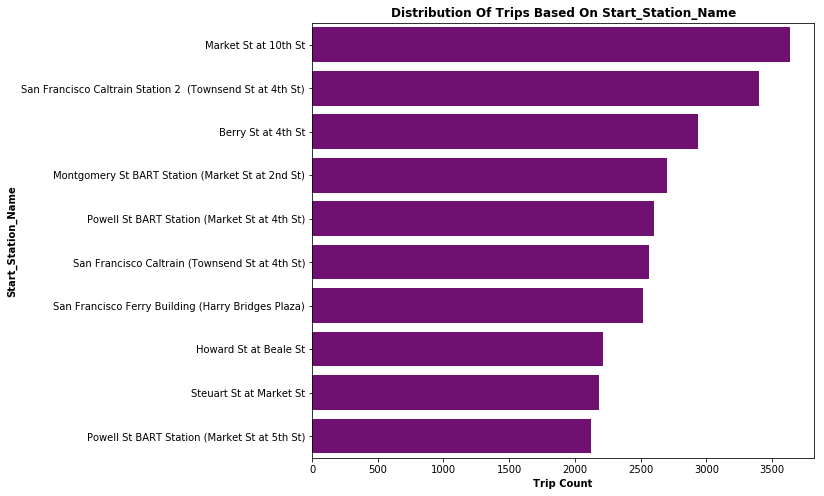

```python
#start stations
top_10_start = ford_bikes_clean['start_station_name'].value_counts().index[:10]
countplot2(ford_bikes_clean, 'start_station_name', color = 'purple', order=top_10_start)
pd.DataFrame(ford_bikes_clean['start_station_name'].value_counts().head(10))
```

|  | end_station_name |
| --- | --- |
| San Francisco Caltrain Station 2 (Townsend St at 4th St) | 4612 |
| Market St at 10th St | 3704 |
| Montgomery St BART Station (Market St at 2nd St) | 3454 |
| San Francisco Ferry Building (Harry Bridges Plaza) | 3133 |
| San Francisco Caltrain (Townsend St at 4th St) | 2856 |
| Powell St BART Station (Market St at 4th St) | 2842 |
| Berry St at 4th St | 2777 |
| The Embarcadero at Sansome St | 2317 |
| Steuart St at Market St | 2259 |
| Powell St BART Station (Market St at 5th St) | 2144 |

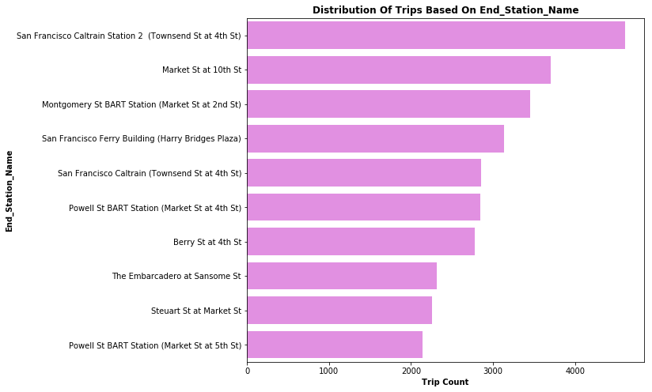

```python
#end stations
top_10_end = ford_bikes_clean['end_station_name'].value_counts().index[:10]
countplot2(ford_bikes_clean, 'end_station_name', color = 'violet', order=top_10_end)
pd.DataFrame(ford_bikes_clean['end_station_name'].value_counts().head(10))
```

### Observation

Market street at 10th street and San Francisco Caltrain station 2 seem to be the most used start and end stations respectively.

### Discuss the distribution(s) of your variable(s) of interest. Were there any unusual points? Did you need to perform any transformations?

> Yes, I added some columns to the dataset like Age, duration in minutes,age group, hour of day, day of the week, etc. I performed some transformations on the Age column and the duration in minutes column by removing outliers. For the Age column, I removed ages greater than 90, and for the duration in mins column, i removed trip durations greater than 100 minutes. This changed the distributions of the Age and trip durations. Also, there were more subscribers than customers.

### Of the features you investigated, were there any unusual distributions? Did you perform any operations on the data to tidy, adjust, or change the form of the data? If so, why did you do this?

> Yes i performed some operations to tidy the data. I converted incorrect datatypes and I added new columns to give me a better insight on the data. I also derived the ages and age groups of members from the birth year information provided. Doing all these gave the data a better view and gave me more insight

## Bivariate Exploration

> In this section, I will investigate relationships between pairs of variables in the dataset. The variables covered here have been introduced in some fashion in the previous section (univariate exploration).

### 7. Trip count in the top 10 start stations based on hour of the day and day of the week

```
Text(0.5,1,'Trip count of top 10 start stations based on hour of the day')
```

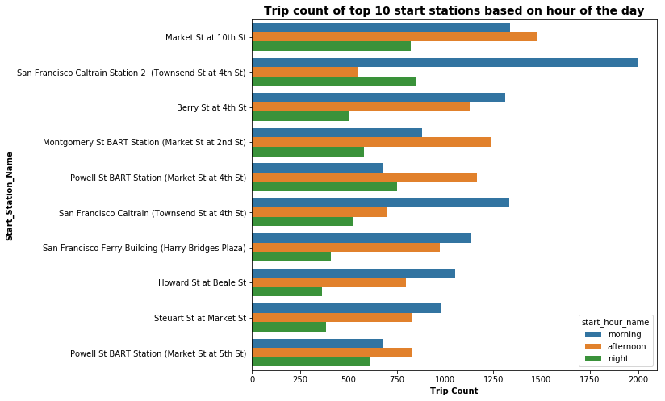

```python
#hour of the day
top_10_start = ford_bikes_clean['start_station_name'].value_counts().index[:10]
bivariate(ford_bikes_clean, 'start_station_name', order=top_10_start, hue='start_hour_name')
plt.title("Trip count of top 10 start stations based on hour of the day", fontsize=14, weight='bold')
```

```
Text(0.5,1,'Trip count of top 10 start stations based on day of the week')
```

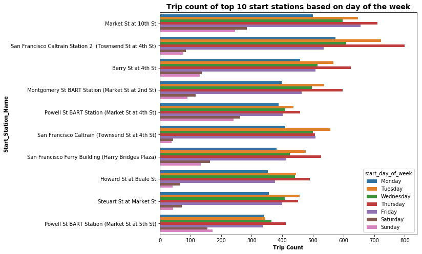

```python
#day of the week
top_10_start = ford_bikes_clean['start_station_name'].value_counts().index[:10]
bivariate(ford_bikes_clean, 'start_station_name', order=top_10_start, hue='start_day_of_week')
plt.title("Trip count of top 10 start stations based on day of the week", fontsize=14, weight='bold')
```

### Observation

1. The first plot confirms that most trips are taken in the morning and afternoon (from our univariate exploration). This plot just shows that most trips from the start stations are in the morning and afternoon. San Francisco caltrain station 2 has the highest number of morning trips while Market street at 10th street has the highest number of rides in the afternoon. Most of the stations still have quite a reasonable number of trips at night.
2. The stations also have more trips from Monday to Friday, and less trips during the weekend, that is Saturday and Sunday.

### 8. Trip count of users based on hour of the day and day of the week

```
Text(0.5,1,'Trip count of users based on hour of the day')
```

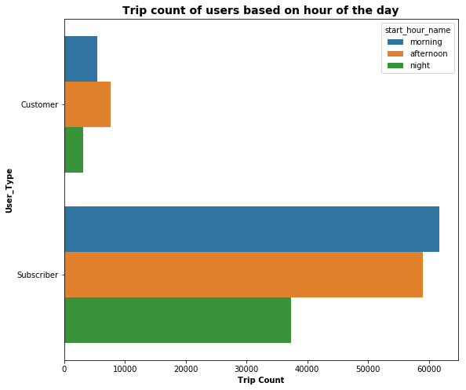

```python
#hour of the day
bivariate(ford_bikes_clean, 'user_type', hue='start_hour_name')
plt.title("Trip count of users based on hour of the day", fontsize=14, weight='bold')
```

```
Text(0.5,1,'Trip count of users based on day of the week')
```

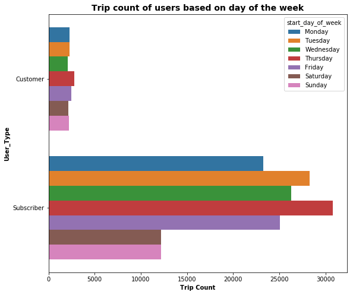

```python
#day of the week
bivariate(ford_bikes_clean, 'user_type', hue='start_day_of_week')
plt.title("Trip count of users based on day of the week", fontsize=14, weight='bold')
```

### Observation

The plots above confirm that there are more subscribers than customers and subscribers take more trips than customers

1. Subscribers take more trips in the morning and afternoon, and a reasonable amount at night. The count for customers is quite low, but they take more afternoon trips
2. Again, subscribers take more trips during the week especially from Monday to friday. Customers might be tourists because of the few amount of trips and subscribers might be San Francisco residents.

### 9. Duration of trips based on age

```
Text(0.5,1,'Duration of trips based on Age of members')
```

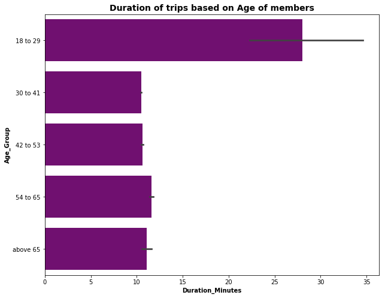

```python
barplots(ford_bikes_clean, 'age_group', x = 'duration_minutes', color = 'purple')
plt.title('Duration of trips based on Age of members', fontsize=14, weight='bold')
```

### 10. Duration of trips to the top 10 end stations(destination stations)

```
Text(0.5,1,'Duration of trips to destination stations')
```

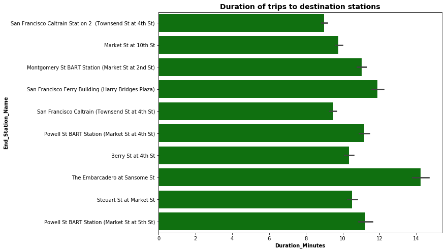

```python
top_10_end = ford_bikes_clean['end_station_name'].value_counts().index[:10]
barplots(ford_bikes_clean, 'end_station_name', x = 'duration_minutes', color = 'green', order=top_10_end)
plt.title('Duration of trips to destination stations', fontsize=14, weight='bold')
```

### Observation

The duration of trips to the destination stations take an average of 10 to 11 minutes. The station with the longest time is the Embarcadero at sansome street station with time of about 14 minutes. This might be dependent on the location of the start station or the route taken by the bike

### Talk about some of the relationships you observed in this part of the investigation. How did the feature(s) of interest vary with other features in the dataset?

> I observed the count of trips based on user type and saw that subscribers take more trips during the week and during the day. I also observed the duration of trips to end stations and saw that the highest duration takes about 14 minutes, maybe because of the route taken by the bike. I also observed the number of trips each stations take based on hour of the day and days of the week. Stations take more trips during the day , that is morning and afternoon, and also from Monday to Friday.

## Multivariate Exploration

> In this section, I am going to create plots of three variables to investigate the data even further.

### 11. Duration of trips per user type based on hour of the day and day of the week

```
Text(0.5,1,'Users trip durations based on hour of the day')
```

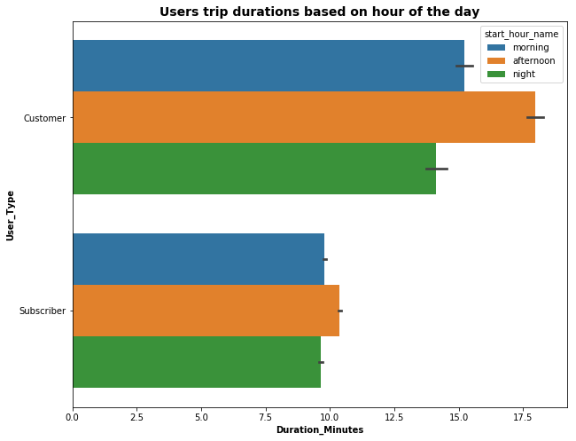

```python
#based on hour of the day
barplots(ford_bikes_clean, 'user_type', x = 'duration_minutes', hue='start_hour_name')
plt.title('Users trip durations based on hour of the day', fontsize=14, weight='bold')
```

```
Text(0.5,1,'Users trip durations based on day of the week')
```

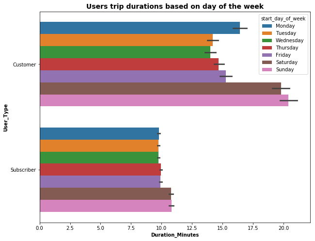

```python
#day of the week
barplots(ford_bikes_clean, 'user_type', x = 'duration_minutes', hue='start_day_of_week')
plt.title('Users trip durations based on day of the week', fontsize=14, weight='bold')
```

### Observation

Customer's trip durations are higher than that of Subscribers in the afternoon, and also higher during weekends (Saturday and Sunday). Lets investigate further by checking the duration of trips for users based on age group

```
Text(0.5,1,'Users trip duration based on age group')
```

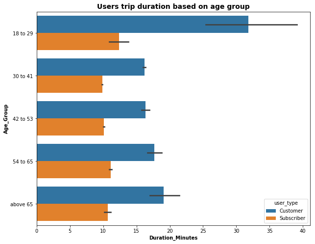

```python
barplots(ford_bikes_clean, 'age_group', x = 'duration_minutes', hue='user_type')
plt.title('Users trip duration based on age group', fontsize=14, weight='bold')
```

### Observation 2

The above plot confirmed that Customers have higher trip durations than subscribers. This may actually mean that these Customers are tourists that go take trips to several locations or farther locations.

### 12. Duration of trips to destination station based on hour of the day and day of the week

```
Text(0.5,1,'Duration of trips to end station based on hour of the day')
```

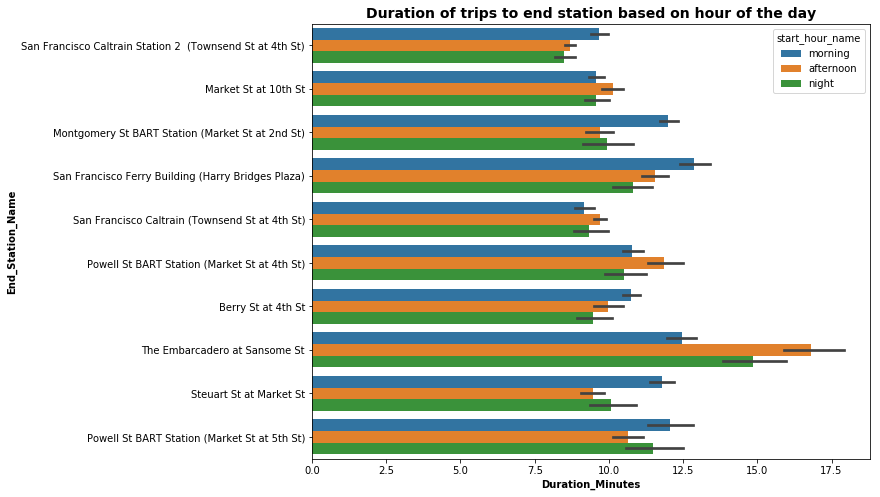

```python
#hour of the day
top_10_end = ford_bikes_clean['end_station_name'].value_counts().index[:10]
barplots(ford_bikes_clean, 'end_station_name', x = 'duration_minutes', hue='start_hour_name', order=top_10_end)
plt.title('Duration of trips to end station based on hour of the day', fontsize=14, weight='bold')
```

```
Text(0.5,1,'Duration of trips to end station based on day of the week')
```

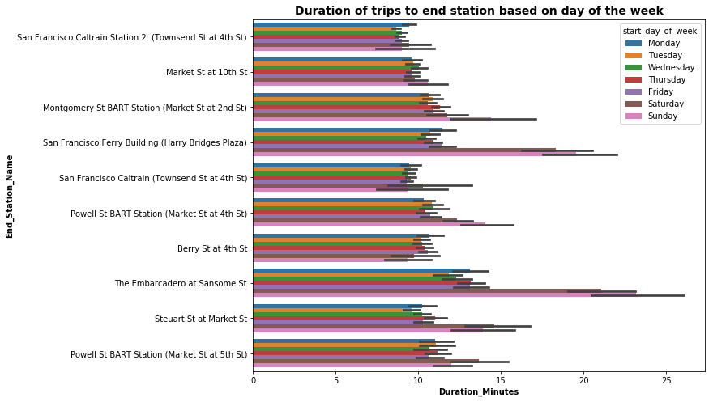

```python
#day of the week
top_10_end = ford_bikes_clean['end_station_name'].value_counts().index[:10]
barplots(ford_bikes_clean, 'end_station_name', x = 'duration_minutes', hue='start_day_of_week', order=top_10_end)
plt.title('Duration of trips to end station based on day of the week', fontsize=14, weight='bold')
```

### Observation

The trip to Embarcadero at Sansome street station is longer in the afternoon and also during the weekends more than other stations. This is also in line with the duration to the station that was investigated earlier.

### Were there any interesting or surprising interactions between features?

> It was quite interesting to see that Customers have longer trips than Subscribers. I was expecting the subscribers to have longer trips because of the fact that they are more than Customers.